# Exploratory data analysis for pig data

# Basic data cleaning

```r
# Load in the pig data
library(data.table)
dt = fread("../data/formatted/full_pig_data.csv")
```

Check for and remove missing lat-long values

```r
ind = is.na(dt$latitude) | is.na(dt$longitude)
sum(ind)
```

```
[1] 15512
```

```r
dt_trun = dt[!ind, ]
dim(dt_trun)
```

```
[1] 1432174       8
```

Pigs between studies can have the same collar number so let’s make unique pig collars.

```r
# Make a unique pigID
dt_trun[, pigID:=paste(collarID, study, sep="")]
```

Dates are not in the same format. Strip all white spcae out of the dates

```r
lmt_date = tstrsplit(dt_trun$lmt_date, " ")[[1]]
dt_trun$lmt_date_strp = lmt_date
```

Combine date and time into one vector

```r
datetime = as.character(paste(dt_trun$lmt_date_strp, dt_trun$lmt_time))
# studies michigan and srel_jim don't have ant seconds on the datetimes..add 00
for(study in c("michigan", "srel_jim")){
  datetime[dt_trun$study == study] = paste(datetime[dt_trun$study == study], ":00", sep="")
}
dt_trun$datetime = as.POSIXct(strptime(datetime, format="%m/%d/%y %H:%M:%S", tz="GMT"))
```

## Some exploratory data analysis

Get the maximum time length at which fixings were taken for each individual pig

```r
fixinfo = dt_trun[, list(study=unique(study),
                         deltat = max(datetime) - min(datetime),
                         numfixes=length(datetime),
                         start=min(datetime),
                         end=max(datetime)), by=list(pigID)]
fixinfo
```

| pigID | study | deltat | numfixes | start | end |
| --- | --- | --- | --- | --- | --- |
| 20125txcamp | txcamp | 165.916655 days | 17234 | 2016-03-03 00:00:11 | 2016-08-15 22:00:10 |
| 20126txcamp | txcamp | 60.916632 days | 7248 | 2016-06-16 00:00:13 | 2016-08-15 22:00:10 |
| 20127txcamp | txcamp | 165.916597 days | 14542 | 2016-03-03 00:00:15 | 2016-08-15 22:00:09 |
| 20130txcamp | txcamp | 104.239248 days | 9085 | 2016-02-29 18:00:38 | 2016-06-12 23:45:09 |
| 20132txcamp | txcamp | 160.989525 days | 17507 | 2016-03-08 00:00:38 | 2016-08-15 23:45:33 |
| 20133txcamp | txcamp | 165.927604 days | 15107 | 2016-03-03 00:00:42 | 2016-08-15 22:16:27 |
| 20134txcamp | txcamp | 163.989167 days | 14245 | 2016-03-05 00:00:58 | 2016-08-15 23:45:22 |
| 20135txcamp | txcamp | 164.989560 days | 15005 | 2016-03-04 00:00:11 | 2016-08-15 23:45:09 |
| 20136txcamp | txcamp | 165.968715 days | 16624 | 2016-03-03 00:00:12 | 2016-08-15 23:15:09 |
| 20137txcamp | txcamp | 163.916354 days | 14824 | 2016-03-05 00:00:38 | 2016-08-15 22:00:11 |

[output cut: 366 more lines]

Any pigs nan?

```r
nanpigs = fixinfo[is.na(fixinfo$deltat), "pigID"]
nanpigs
```

| pigID |
| --- |

All pigs have the correct datetime specifications.

Order by fix times.

```r
fixinfo[order(deltat, decreasing = T)]
```

| pigID | study | deltat | numfixes | start | end |
| --- | --- | --- | --- | --- | --- |
| 16-2-1kilgo | kilgo | 6056.284294 days | 2403 | 2000-01-01 13:12:15 | 2016-07-31 20:01:38 |
| 16-4-2kilgo | kilgo | 838.499537 days | 515 | 2014-01-16 16:01:34 | 2016-05-04 04:00:54 |
| LA_Hart_32856nmovepig | movepig | 655.462500 days | 14908 | 2014-03-22 08:54:00 | 2016-01-06 20:00:00 |
| LA_Hart_33994nmovepig | movepig | 589.875694 days | 3420 | 2014-03-24 02:00:00 | 2015-11-03 23:01:00 |
| LA_Hart_33458n2movepig | movepig | 555.125000 days | 7425 | 2013-03-30 10:00:00 | 2014-10-06 13:00:00 |
| 36635michigan | michigan | 532.726389 days | 5207 | 2014-09-04 09:30:00 | 2016-02-19 02:56:00 |
| 36635srel_jim | srel_jim | 532.726389 days | 5207 | 2014-09-04 09:30:00 | 2016-02-19 02:56:00 |
| GASt_123movepig | movepig | 447.446840 days | 6330 | 2009-02-20 15:24:05 | 2010-05-14 02:07:32 |
| 41_424florida | florida | 419.583183 days | 19063 | 2016-03-05 00:00:34 | 2017-04-28 14:00:21 |
| LA_Hart_34603nmovepig | movepig | 408.213889 days | 8318 | 2014-05-10 11:52:00 | 2015-06-22 17:00:00 |

[output cut: 366 more lines]

Large variation in how long pigs were collared for.

```r
fixinfo[, fixrate:= numfixes / as.numeric(deltat)]
fixinfo[, timeperfix:= (as.numeric(deltat) / numfixes)*24*60]
fixinfo[order(timeperfix, decreasing = F), ]
```

| pigID | study | deltat | numfixes | start | end | fixrate | timeperfix |
| --- | --- | --- | --- | --- | --- | --- | --- |
| 20126txcamp | txcamp | 60.916632 days | 7248 | 2016-06-16 00:00:13 | 2016-08-15 22:00:10 | 118.9822840 | 12.10264 |
| 20139txcamp | txcamp | 59.916331 days | 6815 | 2016-06-17 00:00:38 | 2016-08-15 22:00:09 | 113.7419445 | 12.66024 |
| 20141txcamp | txcamp | 161.916644 days | 18026 | 2016-03-07 00:00:40 | 2016-08-15 22:00:38 | 111.3288888 | 12.93465 |
| 20132txcamp | txcamp | 160.989525 days | 17507 | 2016-03-08 00:00:38 | 2016-08-15 23:45:33 | 108.7462054 | 13.24184 |
| 20125txcamp | txcamp | 165.916655 days | 17234 | 2016-03-03 00:00:11 | 2016-08-15 22:00:10 | 103.8714286 | 13.86329 |
| 20136txcamp | txcamp | 165.968715 days | 16624 | 2016-03-03 00:00:12 | 2016-08-15 23:15:09 | 100.1634553 | 14.37650 |
| 20165txcamp | txcamp | 57.916736 days | 5737 | 2016-06-19 00:00:10 | 2016-08-15 22:00:16 | 99.0559963 | 14.53723 |
| 20145txcamp | txcamp | 165.948241 days | 16252 | 2016-03-03 00:00:10 | 2016-08-15 22:45:38 | 97.9341506 | 14.70376 |
| TXSu_f_hog2movepig | movepig | 36.028472 days | 3426 | 2005-12-12 11:04:00 | 2006-01-17 11:45:00 | 95.0914593 | 15.14332 |
| TXSu_f_hog3movepig | movepig | 29.067361 days | 2747 | 2005-12-12 10:53:00 | 2006-01-10 12:30:00 | 94.5046229 | 15.23735 |

[output cut: 366 more lines]

Let’s look at a distribution of collaring times

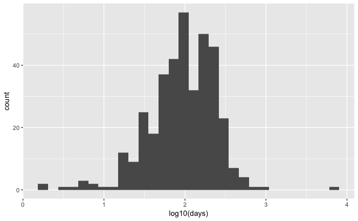

```r
library(ggplot2)
ggplot(fixinfo, aes(x=as.numeric(log10(as.numeric(deltat))))) + geom_histogram() + xlab("log10(days)")
```

Something seems a little wierd with the huge fix time! Will have to check if this pig is an outlier or perhaps the collar just gave a reading when it wasn’t on the pig.

```r
fixinfo[which.max(fixinfo$deltat), ]
```

[output not shown]

Let’s look at deltat by study

```r
ggplot(fixinfo, aes(x=as.numeric(deltat))) + geom_histogram() + facet_wrap(~study)
```

[output not shown]

For each pig by study, let’s look at how long they were tagged for

```r
studies = unique(fixinfo$study)
plots = list()
for(i in 1:length(studies)){

  plots[[i]] = ggplot(data=fixinfo[study==studies[i]], aes(pigID)) + geom_linerange(aes(ymin=start, ymax=end)) +
    facet_wrap(~study, scales = "free") + theme(axis.text.x = element_text(angle = 90, hjust = 1, size=8))
}
```

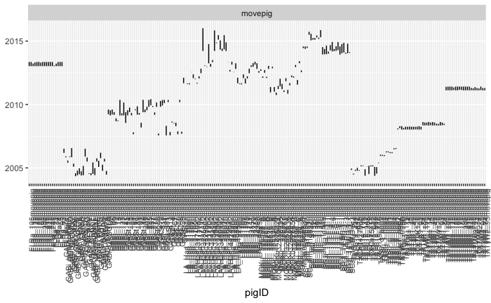

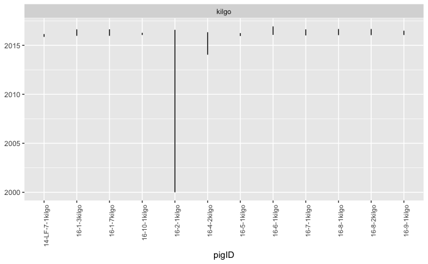

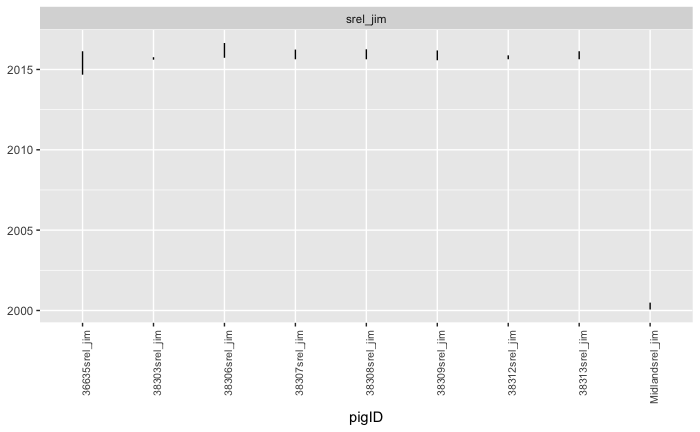

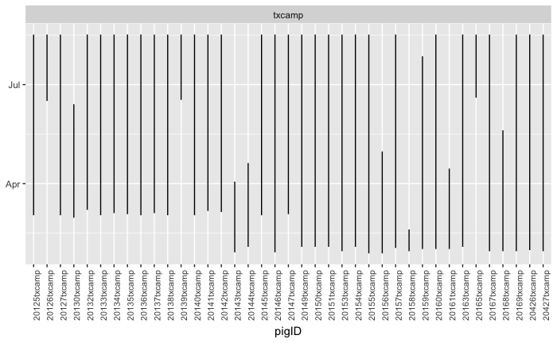

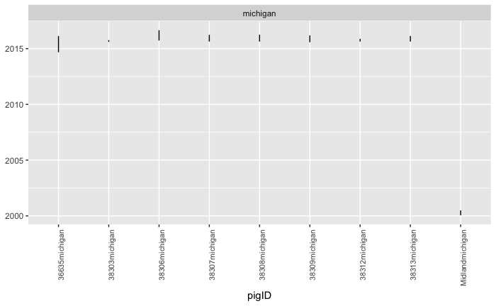

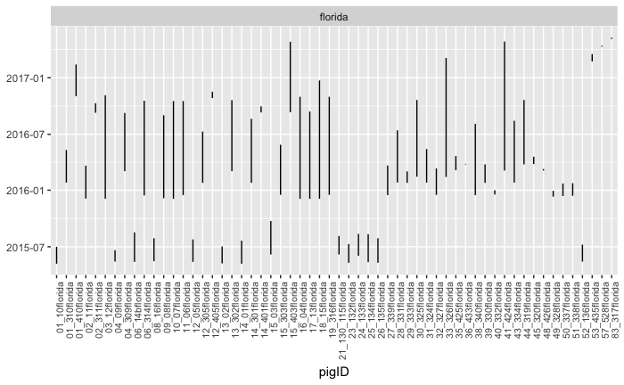

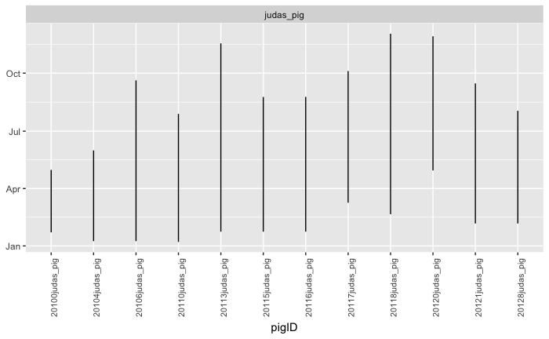

```r
for(i in 1:length(plots)){
  print(plots[[i]])
}
```

Some summary stats by study

```r
# Order the GPS colors by pig and time
dt_trun = dt_trun[order(pigID, datetime)]
diffs = dt_trun[, list(deltat=mean(diff(datetime))), by=list(pigID)]

ggplot(diffs, aes(x=deltat / (60 * 24))) + geom_histogram() + xlab("Days")
```

[output not shown]

## Determing which sequences will be useful for movement analysis

Which pigs have a sequences of at least 10 where each fix is less than 1hr different from the previous fix?

```r
runs = function(x, ctime=60, clength=10){
  # Given a vector of time differneces X
  # determine if the vector has a run of
  # clength or greater of diffs < ctime (in minutes).
  # Parameters
  # ----------
  # x : difference vector of times
  # ctime : Diffs must be less than this time
  # clength : Length of a run

  # Notes
  # -----
  # This will help identify potential trajectories to use for the movement study
  # Returns TRUE or FALSE

  deltat = diff(x)
  inds = deltat < ctime # String of booleans

  # Count runs
  run_vect = rle(inds)
  res = any((run_vect$values == TRUE) & (run_vect$lengths >= clength))
  return(res)

}

long_pigs = dt_trun[, list(longdat=runs(datetime), study=unique(study)), by=pigID]
print(sum(long_pigs$longdat))
print(nrow(long_pigs))
table(long_pigs$study[long_pigs$longdat])
```

[output not shown]

Let’s just focus on these pigs for now.

```r
# Subset data to only include pigs that have the right length of data
keys = long_pigs$pigID[long_pigs$longdat]

# Should be a cleaner and faster way to do this...perhaps with match
inds = rep(FALSE, nrow(dt_trun))
for(key in keys){
  inds = inds | (dt_trun$pigID == key)
}

# Remove the pigs that
movedt = dt_trun[inds]
```

```r
table(movedt$study)
```

[output not shown]

## Plot pig movement trajectories for each study

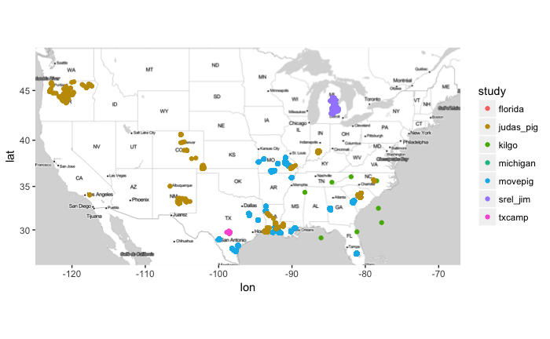

```r
library(ggmap)
# All the pig data
us <- c(left = -125, bottom = 25.75, right = -67, top = 49)
map <- get_stamenmap(us, zoom = 5, maptype = "toner-lite")
ggmap(map) + geom_point(data=dt_trun, aes(x=longitude, y=latitude, color=study))
```

```r
# Pig data that will probably be useful for movement models
us <- c(left = -125, bottom = 25.75, right = -67, top = 49)
map <- get_stamenmap(us, zoom = 5, maptype = "toner-lite")
ggmap(map) + geom_point(data=movedt, aes(x=longitude, y=latitude))
```

[output not shown]

Look at a plot of pig movement in Texas.

```r
library(dplyr)
txcamp = movedt[pigID == "20125txcamp"]
map = get_googlemap(center=c(lon=-98.53675, lat=29.74411), zoom=14, maptype="hybrid") %>% ggmap()
map = map + geom_path(data=txcamp, aes(x=longitude, y=latitude), size=0.5)
map
```

[output not shown]

```r
# Single pig diff
pigdiff = diff(txcamp$datetime)

inds = pigdiff < 100 # String of booleans

  # Count runs
run_vect = rle(inds)
run_vect
```

[output not shown]

```r
write.csv(movedt, "../data/formatted/pig_trajectories.csv")
```